# Data-Explainer

Erin C Rooney

2023-03-15

## Welcome

This is a data explainer for the PhIr Redox Porechem repository. This Markdown file has three goals:

1. List all data products
2. Indicate file names and locations
3. Present a simplified workflow for creating those data products with cleaning and grouping functions. Functions can be edited in the “code/functions_for_dataexplainer.R” script. This goal is under construction. Please refer to actual scripts (1-REDOX-, 2-MOISTURE-TEMP-SALINITY-, 3-FIELD-, 4-ICP-) to see the most up to date and correct functions and code.

View the easy to read published Markdown file [here](https://rpubs.com/ecrooney/1019045).

### Known Issues

- There are two types of information associated sample location: the moisture conditions and the tundra type. Sometimes the tundra type (non-acidic or acidic) is referred to as “area” and sometimes it’s referred to as “site.” Similarly, moisture conditions (dry, mesic, and hydric) are sometimes called “site” and sometimes called “position”.
- There are issues with capitalization. If dataframes aren’t combining, it’s a good chance that the issue is “Dry” and “dry” being unable to merge.
- Sometimes tundra types are referred to as “west” and “east”. West corresponds to non-acidic tundra and east corresponds to acidic tundra. This issue is the result of my data processing being focused on the figures/tables as output.

### Missing Data

I will add in the following datasets as we get them

- rhizon ICP data for 2022
- nutrient data 2021 and 2022

I need to add in the following datasets that we do have

- pH of porewater

## Data Output

**Redox**

“processed/allcombine_2021_frozen.csv”

“processed/allcombine_2022_frozen.csv”

**Moisture Temperature Salinity**

“processed/final_temp_salinity_avgs.csv”

“processed/2022final_temp_salinity_avgs.csv”

**Soil Properties**

“raw/thaw_depth_2021.csv”

“raw/PhIr2021_Soil_Inventory_bd.csv”

“raw/uga_soil_analyses_detectionlimit.csv”

“processed/PhIr2021_Soil_InventoryUTKCores_foranalysis.csv”

**Porewater data**

“raw/PhIr_SOIL_GEOCHEM_results.csv”

“processed/ICP_2022.csv”

“processed/rhizon_2021.csv”

“output/NPOC-TN-PhIr2022.csv”

```r
knitr::opts_chunk$set(echo = FALSE)
```

## All up to date code and functions are located in the “code” folder

**File nomenclature:**

- code/1-REDOX-Step-
- code/2-MOISTURE-TEMP-SALINITY-Step-
- code/3-FIELD-Step-
- code/4-ICP-Step
- code/4-RHIZON-Step
- code/4-TOC-

## Data Input and Processing

## All code and scripts below are out of date. Please instead refer to scripts in “code” folder.

### Source Packages and Functions

### Sensor Data

#### Redox data

artifacts and frozen values removed, standard deviations over a certain range, and with hydrogen electrode correction

```r
knitr::opts_chunk$set(echo = TRUE)

redox_withdepths2022 = read.csv("processed/allcombine_2022_frozen.csv")
redox_withdepths2021 = read.csv("processed/allcombine_2021_frozen.csv")
```

#### Moisture, Temperature, and Salinity

data with artifacts and frozen values removed and with hydrogen electrode correction

```r
temp_sal_moist2021 = read.csv("processed/final_temp_salinity_avgs.csv")
temp_sal_moist2022 = read.csv("processed/2022final_temp_salinity_avgs.csv")
```

#### Soil properties

```r
thaw_depth2021 = read.csv("raw/thaw_depth_2021.csv")
thaw_depth2022 = read.csv("raw/thaw_depth_2022.csv")

bd_grav = read.csv("raw/PhIr2021_Soil_Inventory_bd.csv")
```

### Porewater Data

All porewater data below is in a long format. Pivot wider if a wider format is preferred.

```r
#depths for sipper porewater samples
porewater_ICP_2022 = read.csv("processed/ICP_2022.csv")

#rhizon samplers (only one depth)
porewater_ICP_2021 = read.csv("processed/rhizon_2021.csv")
```

### Cleaning functions

#### Redox cleaning

Everything must be run sequentially

IMPORTANT NOTE: PLEASE SEE 1-REDOX-Step1-Step4 for most accurate and updated code.

```r
#remove frozen data

#avg_values_fixed = redox potential (mV)

redox_unfrozen_2021 = redox2021_remove_frozenpoints_function(redox_withdepths2021)

redox_unfrozen_2022 = redox2022_remove_frozenpoints_function(redox_withdepths2022)

#group by season

#redox_avg_mV = redox potential (mV)

redox_grouped_2021 = redox_2021_groupbytemporal_function(redox_unfrozen_2021)
redox_grouped_2022 = redox_2022_groupbytemporal_function(redox_unfrozen_2022)
```

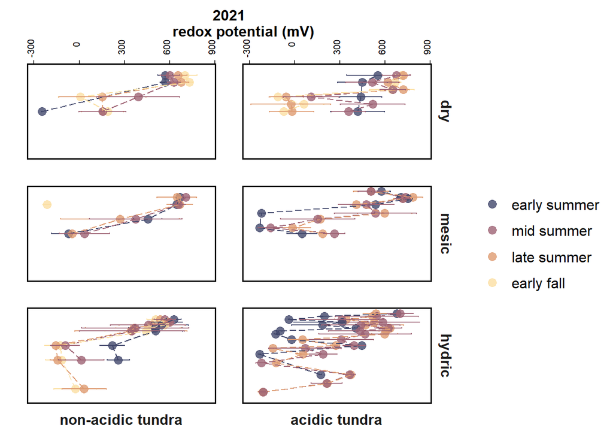

```r
# figure test

redox_grouped_2021 %>%
  mutate(month = factor(month, levels = c("early summer", "mid summer", "late summer", "early fall")))   %>%
  mutate(site = factor(site, levels = c("non-acidic tundra", "acidic tundra"))) %>%
  ggplot(aes(y = depth_cm, x = redox_avg_mV, color = month, fill = month), group = 'position')+
  geom_point(size = 3, alpha = 0.8, shape = c(21))+
  geom_line(orientation = "y", show.legend = FALSE, linetype = "longdash")+
  geom_errorbar(aes(xmin=redox_avg_mV-redox_sd, xmax=redox_avg_mV+redox_sd), show.legend = FALSE)+
  scale_color_manual(values = (pnw_palette('Sunset', 4)))+
  scale_fill_manual(values = (pnw_palette('Sunset', 4)))+
  ylim(60, 0)+
  labs(x = '2021
       redox potential (mV)',
       y = "",
       color = "", fill = "")+
  scale_x_continuous(position="top")+
  facet_grid(position~site, switch = "x")+
  theme_er1()+
  theme(legend.position = "right",
        panel.grid.major = element_blank(), panel.grid.minor = element_blank(),
        panel.background = element_blank(),
        strip.placement = "outside",
        axis.text.y=element_blank(),  #remove y axis labels
        axis.ticks.y=element_blank(),
        axis.text.x = element_text(size = 7.5, hjust=0.8,vjust=0.2,angle = 90))  #remove y axis ticks
```

```r
#remove y axis ticks

# figure test passed. Data is good to go.
```

#### Moisture, Temperature, Salinity Cleaning

IMPORTANT NOTE: PLEASE SEE 2-MOISTURE-TEMP-SALINITY-Step1-Step2 for most accurate and updated code.

```r
#clean up dates, note data as frozen if below -1 C
moisturetempsal2021_cleaned = moisturetempsal_2021_cleaningfunction(temp_sal_moist2021)
moisturetempsal2022_cleaned = moisturetempsal_2022_cleaningfunction(temp_sal_moist2022)

#grouped temporal data

moisturetempsal2021_grouped = moisturetempsal_2021_groupfunction(moisturetempsal2021_cleaned)
moisturetempsal2022_grouped = moisturetempsal_2022_groupfunction(moisturetempsal2022_cleaned)
```

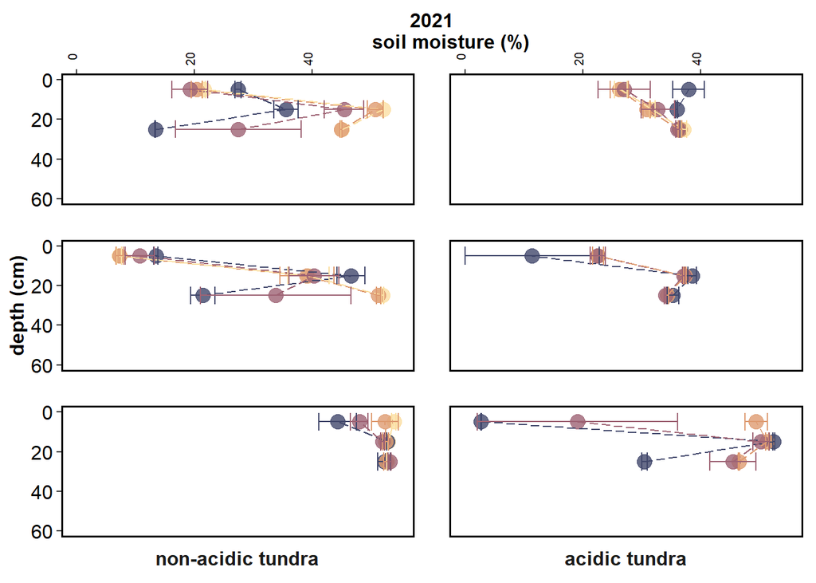

```r
 moisturetempsal2021_grouped %>%
  mutate(month = factor(month, levels = c("early summer", "mid summer", "late summer", "early fall")))   %>%
  mutate(site = factor(site, levels = c("non-acidic tundra", "acidic tundra"))) %>%
  ggplot(aes(y = depth_cm, x = moisture_avg, color = month, fill = month), group = 'month')+
  geom_point(size = 4, alpha = 0.8, shape = c(21))+
  geom_line(orientation = "y", show.legend = FALSE, linetype = "longdash")+
  geom_errorbar(aes(xmin=moisture_avg-moisture_sd, xmax=moisture_avg+moisture_sd), show.legend = FALSE)+
  scale_color_manual(values = (pnw_palette('Sunset', 4)))+
  scale_fill_manual(values = (pnw_palette('Sunset', 4)))+
  ylim(60, 0)+
  labs(x = '2021
       soil moisture (%)',
       y = "depth (cm)",
       color = "", fill = "")+
  scale_x_continuous(position="top")+
  facet_grid(position~site, switch = "x")+
  theme_er1()+
  theme(legend.position = "none",
        panel.grid.major = element_blank(), panel.grid.minor = element_blank(),
        panel.background = element_blank(),
        strip.placement = "outside",
        strip.text.y = element_blank(),
        axis.text.x = element_text(size = 7.5, hjust=0.8,vjust=0.2,angle = 90))
```

#### Soil properties cleaning

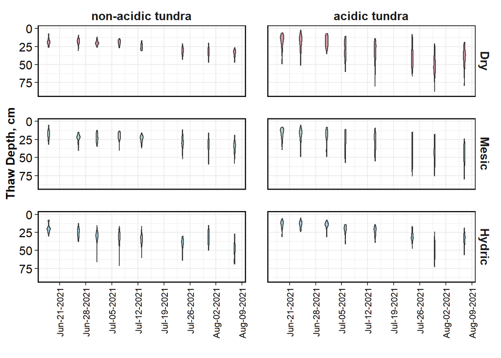

```r
#clean up data, rename areas for consistency, calculate volumetric moisture, simplify soil material type
bd_cleaned = soil_properties_cleaningfunction(bd_grav)

#select only necessary columns, simplify date-plot labels, set levels for material/horizons and date-plots, group by Area, Site, Horizon and summarise mean and sd for bulk density and volumetric water content

bd_grouped = soil_properties_groupingfunction(bd_cleaned)
#thaw depth cleaning

thawdepths_2021_cleaned = thawdepths_2021_cleaningfunction(thaw_depth2021)
thawdepths_2022_cleaned = thawdepths_2022_cleaningfunction(thaw_depth2022)


#thaw depth figure test

thawdepths_2021_cleaned %>%
  mutate(Site = factor(Site, levels = c("Dry", "Mesic", "Hydric"))) %>%
  #filter(Area == "non-acidic tundra") %>%
  ggplot()+
  geom_violin(aes(x = as.Date(date2), y = thaw_depth_cm, group = as.Date(date2), fill = Site), alpha = 0.4)+
  labs(x = " ",
       y = "Thaw Depth, cm")+
  #geom_rect(aes(xmin=as_date('2021-06-15'), xmax= as_date('2021-08-09'), ymin=49.5, ymax=50.5), fill = "black")+
  #scale_fill_gradientn(colors = natparks.pals(name = "Banff"))+
  scale_fill_manual(values = c("#9a031e", "#40916c", "#118ab2"))+
  scale_x_date(date_breaks = "1 week", date_labels = "%b-%d-%Y")+
  ylim(90, 0)+
  facet_grid(Site~Area)+
  theme_er1()+
  theme(legend.position = "none", axis.text.x = element_text (vjust = 0.5, hjust=1, angle = 90, size = 9))
```

```r
#bulk density figure test
```

#### Porewater cleaning

```r
#cleaning
porewater_ICP_2021_cleaned = rhizon_cleaningfunction(porewater_ICP_2021)

#2022 ICP sipper porewater data comes pre-cleaned

#grouping
porewater_ICP_2021_grouped = rhizon_groupingfunction(porewater_ICP_2021_cleaned)
```

[output not shown]

```r
porewater_ICP_2022_grouped = sipper_groupingfunction(porewater_ICP_2022)
```

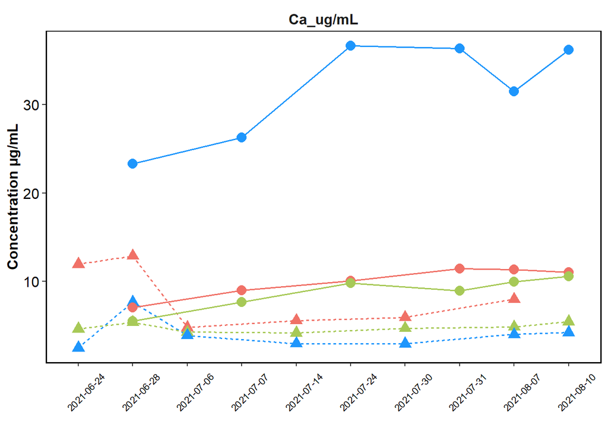

```r
#rhizon 2021 test figure

 porewater_ICP_2021_grouped %>%
  mutate(Area = recode(Area, "West" = "non-acidic tundra",
                       "East" = "acidic tundra")) %>%
  mutate(Area = factor(Area, levels = c("non-acidic tundra", "acidic tundra"))) %>%
  filter(ICP %in% c("Ca_ug/mL")) %>%
  # mutate(ICP = recode(ICP, "calcium" = "calcium μg/mL",
  #                     "iron" = "iron μg/mL",
  #                     "aluminum" = "aluminum μg/mL",
  #                     "phosphorus" = "phosphorus μg/mL")) %>%
  ggplot(aes(x = Betterdate, y = mean, color = Site)) +
  geom_line(aes(group = area_site, linetype = Area), size = 0.7, orientation = "x")+
  geom_point(aes(group = area_site, shape = Area), size = 3.5)+
  # scale_fill_gradientn(colors = (pnw_palette("Shuksan2")))+
  # scale_color_gradientn(colors = (pnw_palette("Shuksan2")))+
  scale_fill_manual(values = c("#f07167", "#a7c957", "#1e96fc", "#f07167", "#a7c957", "#1e96fc"))+
  scale_color_manual(values = c("#f07167", "#a7c957", "#1e96fc", "#f07167", "#a7c957", "#1e96fc"))+
  labs(color = "Moisture",
       linetype = "Acidity",
       y = "Concentration μg/mL",
       x = " ")+
  facet_grid(. ~ ICP, scales = "free_y") +
  theme_er1()+
  theme(axis.text.x = element_text(size = 8, hjust=0.25,vjust=0.2,angle = 45), legend.position = "none",
        panel.grid.major = element_blank(), panel.grid.minor = element_blank(),
        panel.background = element_blank())
```

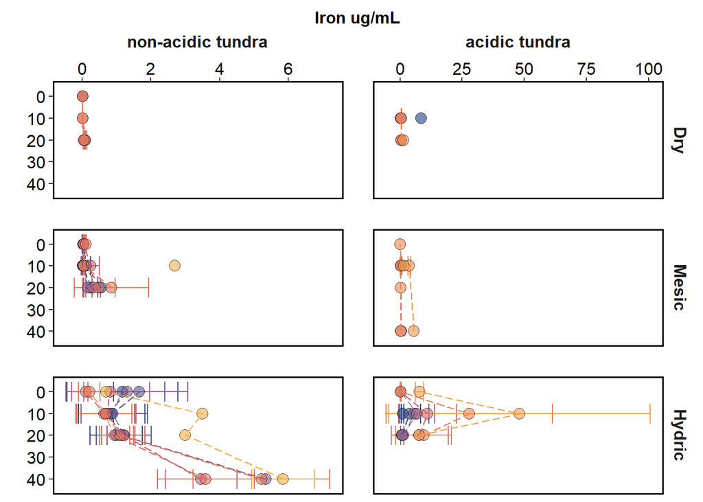

```r
# sipper 2022 test figure

   porewater_ICP_2022_grouped %>%
    filter(ICP == "Fe_ug_mL") %>%
    mutate(Area = factor(Area, levels = c("non-acidic tundra", "acidic tundra"))) %>%
    mutate(Site = factor(Site, levels = c("Dry", "Mesic", "Hydric"))) %>%
    ggplot(aes(x = mean, y = Depth_cm, fill = date_plot, group = date_plot)) +
    geom_errorbar(aes(xmin=(mean - sd), xmax=(mean + sd), color = date_plot))+
    geom_point(size = 3.5, shape = c(21), alpha = 0.6)+
    geom_line(aes(color = date_plot), orientation = "y", linetype = "longdash")+
    # scale_fill_gradientn(colors = (pnw_palette("Shuksan2")))+
    # scale_color_gradientn(colors = (pnw_palette("Shuksan2")))+
    scale_fill_manual(values = (pnw_palette("Sunset2", 15)))+
    scale_color_manual(values = (pnw_palette("Sunset2", 15)))+
    labs(fill = "Date",
         color = "Date",
         y = "",
         x = "Iron ug/mL")+
    scale_y_reverse()+
    scale_x_continuous(position = 'top') +
    facet_grid(Site ~ Area, scales = "free_x")+
    theme_er1()+
    theme(legend.position = "none",
          panel.grid.major = element_blank(), panel.grid.minor = element_blank(),
          panel.background = element_blank(),
                strip.placement = "outside")
```

##Out of date files

BELOW FILES ARE NOT UPDATED.

```r
#Redox

write.csv(redox_withdepths2021, "modeling-data-output-files/redox_withdepths2021.csv")
write.csv(redox_withdepths2022, "modeling-data-output-files/redox_withdepths2022.csv")

write.csv(redox_unfrozen_2021, "modeling-data-output-files/redox_unfrozen_2021.csv")
write.csv(redox_unfrozen_2022, "modeling-data-output-files/redox_unfrozen_2022.csv")

write.csv(redox_grouped_2021, "modeling-data-output-files/redox_grouped_2021.csv")
write.csv(redox_grouped_2022, "modeling-data-output-files/redox_grouped_2022.csv")



#Moisture Temperature Salinity
write.csv(temp_sal_moist2021, "modeling-data-output-files/temp_sal_moist2021.csv")
write.csv(temp_sal_moist2022, "modeling-data-output-files/temp_sal_moist2022.csv")

write.csv(moisturetempsal2021_cleaned, "modeling-data-output-files/moisturetempsal2021_cleaned.csv")
write.csv(moisturetempsal2022_cleaned, "modeling-data-output-files/moisturetempsal2022_cleaned.csv")

write.csv(moisturetempsal2021_grouped, "modeling-data-output-files/moisturetempsal2021_grouped.csv")
write.csv(moisturetempsal2022_grouped, "modeling-data-output-files/moisturetempsal2022_grouped.csv")




#Porewater data
write.csv(porewater_ICP_2021, "modeling-data-output-files/porewater_ICP_2021.csv")
write.csv(porewater_ICP_2022, "modeling-data-output-files/porewater_ICP_2022.csv") #comes cleaned
write.csv(porewater_ICP_2021_cleaned, "modeling-data-output-files/porewater_ICP_2021_cleaned.csv")
write.csv(porewater_ICP_2021_grouped, "modeling-data-output-files/porewater_ICP_2021_grouped.csv")
write.csv(porewater_ICP_2022_grouped, "modeling-data-output-files/porewater_ICP_2022_grouped.csv")


#Soil Properties

write.csv(thawdepths_2021_cleaned, "modeling-data-output-files/thawdepths_2021_cleaned.csv")
write.csv(thawdepths_2022_cleaned, "modeling-data-output-files/thawdepths_2022_cleaned.csv")
write.csv(bd_grav, "modeling-data-output-files/bd_grav.csv")
write.csv(bd_cleaned, "modeling-data-output-files/bd_cleaned.csv")
write.csv(bd_grouped, "modeling-data-output-files/bd_grouped.csv")
```